# R Notebook

# Check how indivisuals cure by surjury.

input data: - /home/rstudio/work/data/ClinicalTable Cell Reports.txt

workflow1: Q1. Is change of body feature (reduce amount of BMI and/or Waist/Hip value …) is correspond to change of the expression profile cluster?

1. Cluster indivisual by BMI and/or Waist/Hip value … (OB - POB value of body condition)
2. Cluster indivisual by OB - POB count of insuline responde gene profile.
3. Compare 1 and 2 cluster with rand index to conclude similality of the cluster.

Problem: Is it OK to just OB - POB count? Need normalization? -> It would be better not to take difference of insuline responde gene profile, but extract insuline response gene in sub group.

Workflow2: 1. Modify table to have 2 column OB vs POB.  
2. Check the distribution of OB - POB value of clinic values to get sub groups of the indivisuals. -> better cured vs less cured 3. extract insulin response gene in those sub groups. 4. Check the different insulin response gene between OB sub and POB sub group -> extention of Fig2a.

Q2. Dose 7 enriched TF has same activity ratio though the target? 1. create small directed network of 7 TFs to insuline responde gene. 2. culculate ratio of the target activity (induce, attenuate) 3. Find TF which is commonly enriched but differentry active the targets.

-> This analysis may not be find difference because correlation of the insulin responce gene profile between groups in FigureS2 shows correlation.

# Q1

```r
clinic <- read_tsv("~/work/data/ClinicalTable Cell Reports.txt")
```

## indivisual difference between OB vs POB

Add W/H value which is also one of the score to varidate obisity.

```r
clinic$wh <- clinic$Waist / clinic$Hip
```

get person ID to get match of person.

```r
clinic$ID <- substr(clinic$Patnr, start = 3, stop = nchar(clinic$Patnr))
clinic$Location <- substr(clinic$Patnr, start = 1, stop = 2)
```

```r
clinic %>%
  filter(!Gender == "M") %>%
  filter(Location == "NO") %>%
  drop_na() %>%
  group_by(Type) %>%
  count()
```

| Type | n |
| --- | --- |
| OBESE | 53 |
| POST_OBESE | 48 |

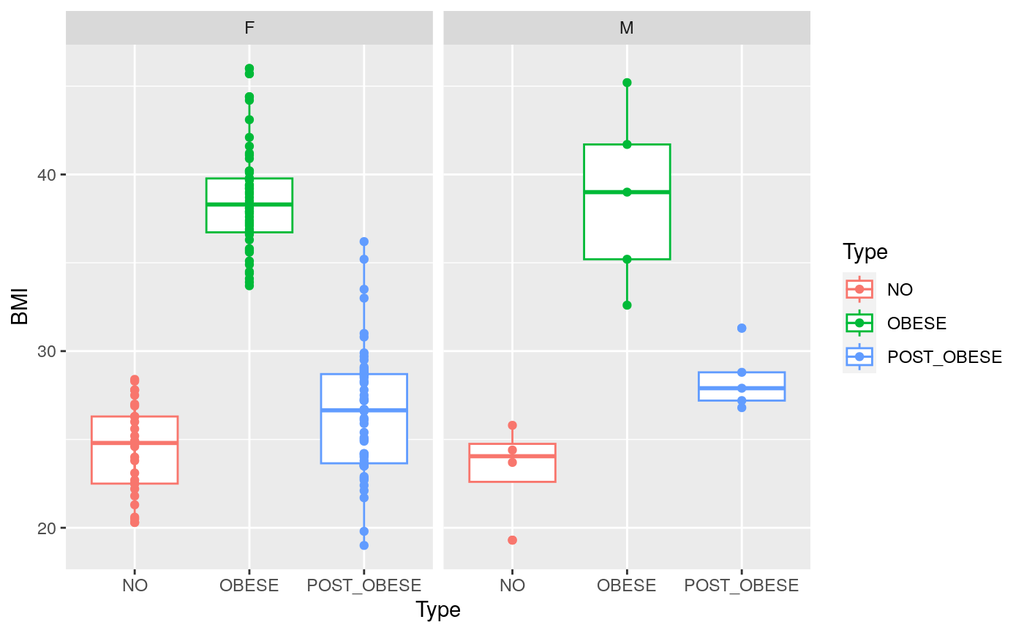

```r
p <- ggplot(clinic,aes(x=Type, y=BMI, color = Type)) +
  geom_boxplot(aes(color = Type)) +
  geom_point(aes(color = Type)) +
  geom_line(aes(group=interaction(Type,ID))) +
  facet_wrap(~Gender, ncol=2)
print(p)
```

```r
p <- ggplot(clinic,aes(x=Type, y=wh, color = Type)) +
  geom_boxplot(aes(color = Type)) +
  geom_point(aes(color = Type)) +
  facet_wrap(~Gender, ncol=2)
print(p)
```

[output not shown]

```r
p <- ggplot(clinic,aes(x=Type, y=wh, color = Type)) +
  geom_boxplot(aes(color = Type)) +
  geom_point(aes(color = Type)) +
  facet_wrap(~Gender, ncol=2)
print(p)
```

[output not shown]